# Decision Tree

Claire Yoon (ndq7xj)

2023-01-04

#### Read in the data

```r
#water_quality <- read.csv("/Users/stephaniefissel/Library/Mobile Documents/com~apple~CloudDocs/ds final project/water_potability.csv")
water_quality <- read.csv("~/Desktop/R/water-quality-project/water_potability.csv")
```

### Clean the data

There were 1/3 missing values in Sulfate variable, but we didn’t delete it because sulfate showed one of the crucial factors for predicting non-potability because it leads to diarrhea and some problems. After handling with the missing values, we have 2011 objects.

```r
water_quality <- water_quality[complete.cases(water_quality), ]
#dim(water_quality)
```

### Rename and factorize the ‘Potability’ variable

We renamed the categorical values (1 and 0) to “potable” and “non_potable”

```r
water_quality$Potability <- as.factor(water_quality$Potability)
water_quality$Potability <- fct_collapse(water_quality$Potability,
                           potable = "1",
                           non_potable = "0")
table(water_quality$Potability)
```

```
##
## non_potable     potable
##        1200         811
```

```r
str(water_quality)
```

```
## 'data.frame':    2011 obs. of  10 variables:
##  $ ph             : num  8.32 9.09 5.58 10.22 8.64 ...
##  $ Hardness       : num  214 181 188 248 203 ...
##  $ Solids         : num  22018 17979 28749 28750 13672 ...
##  $ Chloramines    : num  8.06 6.55 7.54 7.51 4.56 ...
##  $ Sulfate        : num  357 310 327 394 303 ...
##  $ Conductivity   : num  363 398 280 284 475 ...
##  $ Organic_carbon : num  18.4 11.6 8.4 13.8 12.4 ...
##  $ Trihalomethanes: num  100.3 32 54.9 84.6 62.8 ...
##  $ Turbidity      : num  4.63 4.08 2.56 2.67 4.4 ...
##  $ Potability     : Factor w/ 2 levels "non_potable",..: 1 1 1 1 1 1 1 1 1 1 ...
```

```r
#glimpse(water_quality)
```

### We had a weird issue that the values (potable and non_potable) of “Potability” variable was switched even though we labeled them correctly. So, it shows the swap between sensitivity and specificity. But, the correct value is potable = 1 and non_potable = 0.

### Splitting the data with tuning and test & Creating Decision Trees

#### First Decision Tree Model

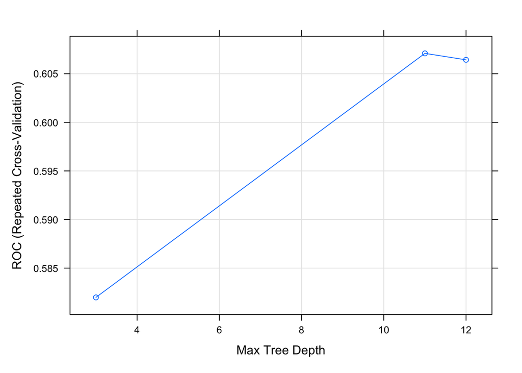

```r
#We do not need to check for correlated variables because correlation does not impact decision trees.
#Decision trees make greedy, localized decisions that are not dependent on previous steps or other variables in the tree model.
set.seed(777)
partition <- caret::createDataPartition(water_quality$Potability,
                                           times=1,
                                           p = 0.80,
                                           groups=1,
                                           list=FALSE)
train <- water_quality[partition, ]
tune_and_test <- water_quality[-partition, ]
#train

tune_and_test_index <- createDataPartition(tune_and_test$Potability,
                                           p = .5,
                                           list = FALSE,
                                           times = 1)

tune <- tune_and_test[tune_and_test_index, ]
test <- tune_and_test[-tune_and_test_index, ]

# Build the model
# Choose the features and classes, slightly different approach for caret, need to create features and target sets from the training data.
#str(water_quality)
features <- train[,-10] # dropping the target variable
target <- train$Potability
#str(features)

#str(target)
fitControl <- trainControl(method = "repeatedcv",
                          number = 10,
                          repeats = 5,
                          classProbs = TRUE,
                          summaryFunction = twoClassSummary)

# Train the model without setting tree grid
set.seed(777)
water_mdl1 <- train(x=features,
                y=target,
                method="rpart2",
                trControl=fitControl,
                metric="ROC")
plot(water_mdl1)
```

```r
varImp(water_mdl1)
```

```
## rpart2 variable importance
##
##                 Overall
## ph              100.000
## Sulfate          81.225
## Chloramines      55.675
## Hardness         55.425
## Solids           55.415
## Trihalomethanes  22.920
## Conductivity     19.896
## Turbidity         2.489
## Organic_carbon    0.000
```

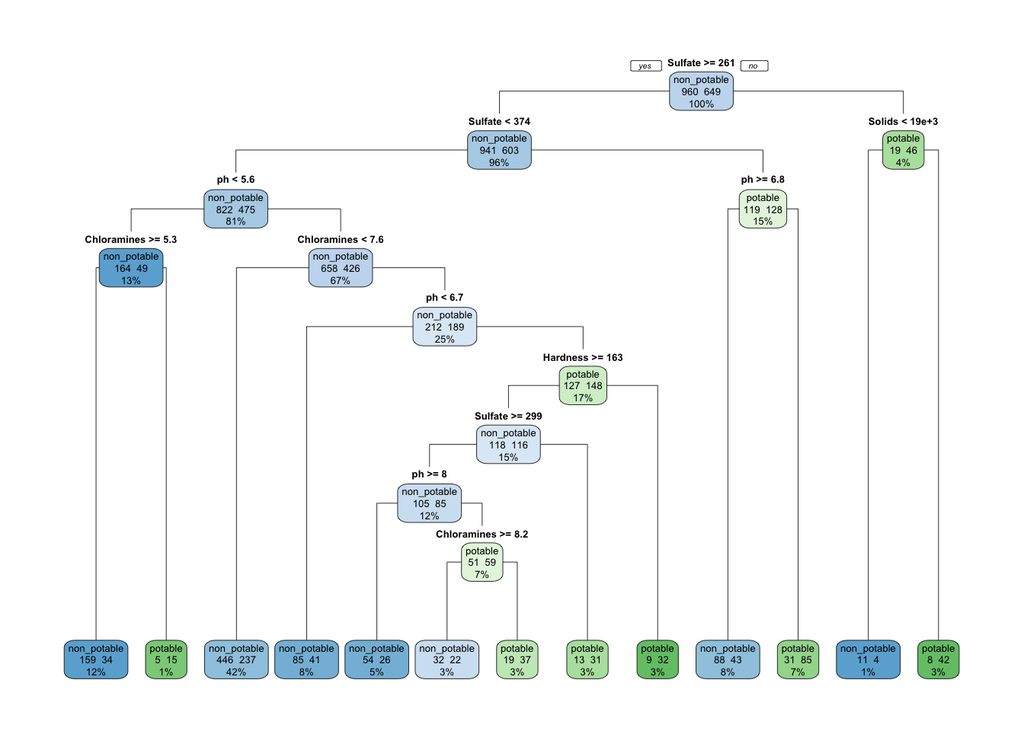

```r
rpart.plot(water_mdl1$finalModel, type=1,extra=101)
```

```r
water_mdl1 # maxdepth is 11
```

```
## CART
##
## 1609 samples
##    9 predictor
##    2 classes: 'non_potable', 'potable'
##
## No pre-processing
## Resampling: Cross-Validated (10 fold, repeated 5 times)
## Summary of sample sizes: 1448, 1448, 1448, 1448, 1448, 1448, ...
## Resampling results across tuning parameters:
##
##   maxdepth  ROC        Sens       Spec
##    3        0.5819893  0.8922917  0.2486827
##   11        0.6070960  0.8260417  0.3445192
##   12        0.6064304  0.8304167  0.3387212
##
## ROC was used to select the optimal model using the largest value.
## The final value used for the model was maxdepth = 11.
```

```r
dims <- data.frame("Train Size" = nrow(train), "Tune Size" = nrow(tune), "Test Size" = nrow(test))  # create a dataframe of the sizes of each set and output the dataframe
dims
```

```
##   Train.Size Tune.Size Test.Size
## 1       1609       201       201
```

#### Second Decision Tree Model

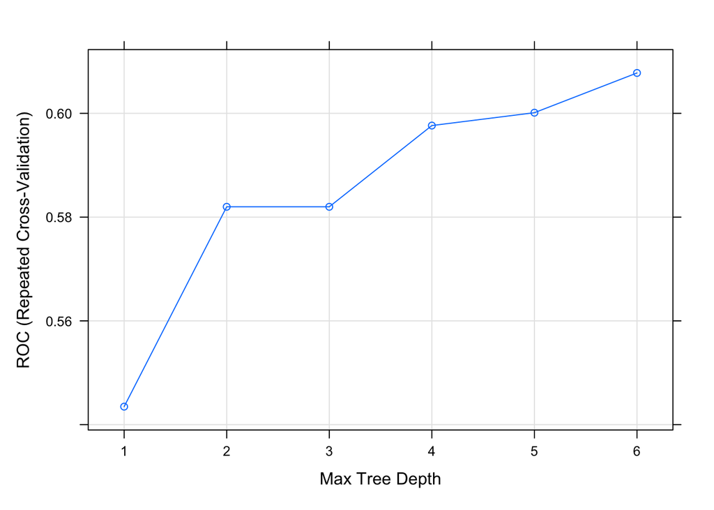

```r
# Train the model
tree.grid <- expand.grid(maxdepth=c(1:6))
set.seed(777)
water_mdl2 <- train(x=features,
                y=target,
                method="rpart2",
                trControl=fitControl,
                tuneGrid=tree.grid,
                metric="ROC")

plot(water_mdl2)
```

```r
varImp(water_mdl2)
```

```
## rpart2 variable importance
##
##                 Overall
## ph              100.000
## Sulfate          75.630
## Chloramines      56.055
## Solids           55.379
## Hardness         47.793
## Trihalomethanes  26.922
## Conductivity      8.764
## Turbidity         4.527
## Organic_carbon    0.000
```

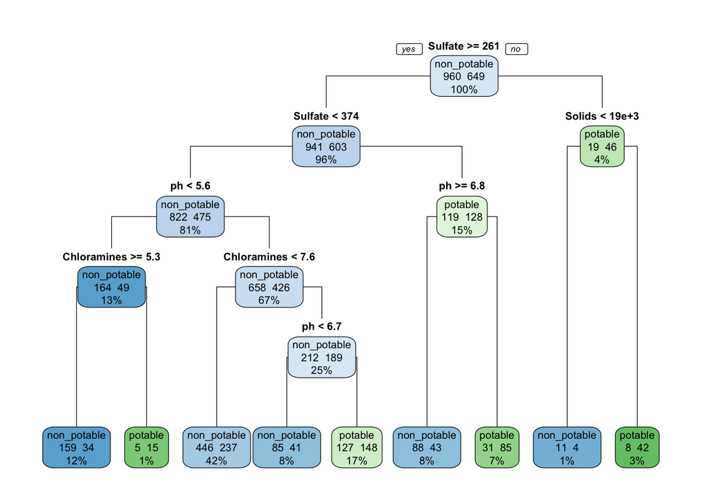

```r
rpart.plot(water_mdl2$finalModel, type=1,extra=101)
```

```r
water_mdl2 # maxdepth is 6
```

```
## CART
##
## 1609 samples
##    9 predictor
##    2 classes: 'non_potable', 'potable'
##
## No pre-processing
## Resampling: Cross-Validated (10 fold, repeated 5 times)
## Summary of sample sizes: 1448, 1448, 1448, 1448, 1448, 1448, ...
## Resampling results across tuning parameters:
##
##   maxdepth  ROC        Sens       Spec
##   1         0.5434693  0.9381250  0.1411250
##   2         0.5819893  0.8922917  0.2486827
##   3         0.5819893  0.8922917  0.2486827
##   4         0.5976481  0.8491667  0.3093990
##   5         0.6001289  0.8375000  0.3226971
##   6         0.6077882  0.8372917  0.3266827
##
## ROC was used to select the optimal model using the largest value.
## The final value used for the model was maxdepth = 6.
```

### Confusion Matrix, Statistics, and Density Plot on Two Decision Trees

#### First Model

```r
predictandCM<- function(model,data,modeltype,ref)
{
  pred <-predict(model,data,type=modeltype)
  confusionMatrix(pred, reference=ref, positive = 'potable')
}

predictandCM(water_mdl1, tune, "raw", tune$Potability)
```

```
## Confusion Matrix and Statistics
##
##              Reference
## Prediction    non_potable potable
##   non_potable         111      54
##   potable               9      27
##
##                Accuracy : 0.6866
##                  95% CI : (0.6175, 0.75)
##     No Information Rate : 0.597
##     P-Value [Acc > NIR] : 0.005413
##
##                   Kappa : 0.284
##
##  Mcnemar's Test P-Value : 2.965e-08
##
##             Sensitivity : 0.3333
##             Specificity : 0.9250
##          Pos Pred Value : 0.7500
##          Neg Pred Value : 0.6727
##              Prevalence : 0.4030
##          Detection Rate : 0.1343
##    Detection Prevalence : 0.1791
##       Balanced Accuracy : 0.6292
##
##        'Positive' Class : potable
##
```

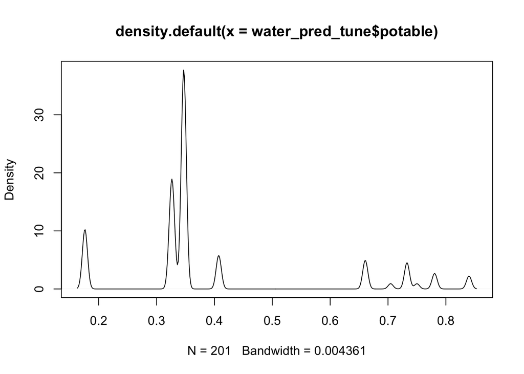

```r
water_pred_tune = predict(water_mdl1,tune,tune$Potability, type= "prob")
water_pred_tune_labels = predict(water_mdl1,tune,tune$Potability,type = "raw")
plot(density(water_pred_tune$potable))
```

```r
predictandCM(water_mdl2, tune, "raw", tune$Potability)
```

```
## Confusion Matrix and Statistics
##
##              Reference
## Prediction    non_potable potable
##   non_potable          95      47
##   potable              25      34
##
##                Accuracy : 0.6418
##                  95% CI : (0.5713, 0.708)
##     No Information Rate : 0.597
##     P-Value [Acc > NIR] : 0.11030
##
##                   Kappa : 0.2212
##
##  Mcnemar's Test P-Value : 0.01333
##
##             Sensitivity : 0.4198
##             Specificity : 0.7917
##          Pos Pred Value : 0.5763
##          Neg Pred Value : 0.6690
##              Prevalence : 0.4030
##          Detection Rate : 0.1692
##    Detection Prevalence : 0.2935
##       Balanced Accuracy : 0.6057
##
##        'Positive' Class : potable
##
```

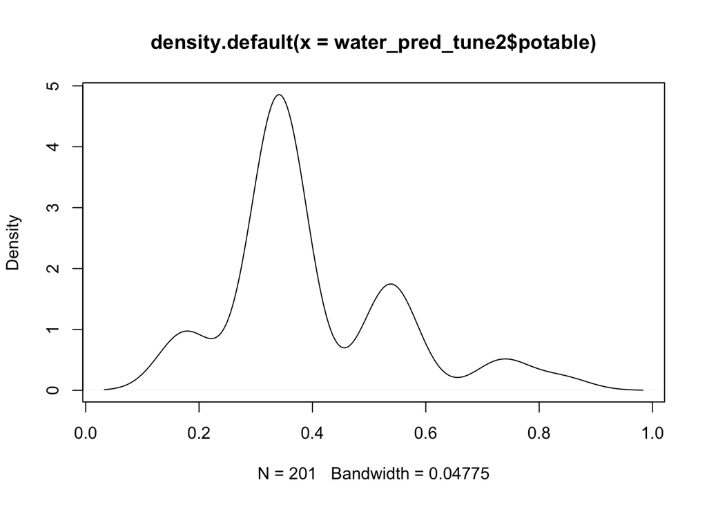

```r
water_pred_tune2 = predict(water_mdl2,tune,tune$Potability, type= "prob")
water_pred_tune_labels2 = predict(water_mdl2,tune,tune$Potability,type = "raw")
plot(density(water_pred_tune2$potable))
```

### Understanding Confusion Matrix

Considering the real world situation, False Negative does not cause detrimental effects because people do not drink water if it is identified as non-potable even though it is actually potable. However, the opposite case (False Positive) will cause significant problems (people will be sick), so we need to make sure to reduce the number of False Positive and the model should be reliable.

### Sensitivity & Specificity

Sensitivity = number of true positives / (number of true positives + number of false negatives)  
= number of correctly identified as potable water / total number of potable water

Specificity = number of true negatives / (total number of true negatives + number of false positives)  
= number of correctly identified as non-potable water / total number of non-potable water  
Our goal is to reduce the number of False Positive and get higher Specificity

```r
# Use the the confusion matrix function on your predictions to check a variety of metrics and comment on the metric that might be best for this type of analysis given your question.

water_eval <- caret::confusionMatrix(water_pred_tune_labels2,
                as.factor(tune$Potability),
                dnn=c("Prediction", "Actual"),
                positive="potable",
                mode = "everything")
water_eval
```

```
## Confusion Matrix and Statistics
##
##              Actual
## Prediction    non_potable potable
##   non_potable          95      47
##   potable              25      34
##
##                Accuracy : 0.6418
##                  95% CI : (0.5713, 0.708)
##     No Information Rate : 0.597
##     P-Value [Acc > NIR] : 0.11030
##
##                   Kappa : 0.2212
##
##  Mcnemar's Test P-Value : 0.01333
##
##             Sensitivity : 0.4198
##             Specificity : 0.7917
##          Pos Pred Value : 0.5763
##          Neg Pred Value : 0.6690
##               Precision : 0.5763
##                  Recall : 0.4198
##                      F1 : 0.4857
##              Prevalence : 0.4030
##          Detection Rate : 0.1692
##    Detection Prevalence : 0.2935
##       Balanced Accuracy : 0.6057
##
##        'Positive' Class : potable
##
```

```r
# estimate the target variable.
set.seed(777)  # set seed
pred_tune = predict(water_mdl2,tune)  # predict using the model on the tune set

pred_tune_prob <- predict(water_mdl2,tune, tune, type = "prob")  # save the raw probabilities for each observation being in the positive or negative class

probs_and_results <- cbind(pred_tune_prob, data.frame(`actual_potability`= tune$Potability))

head(probs_and_results)
```

```
##     non_potable   potable actual_potability
## 37    0.8238342 0.1761658       non_potable
## 54    0.6530015 0.3469985       non_potable
## 96    0.6746032 0.3253968       non_potable
## 125   0.4618182 0.5381818       non_potable
## 132   0.8238342 0.1761658       non_potable
## 151   0.4618182 0.5381818       non_potable
```

### Adjusting Threshold with the Second Decision Tree Model

```r
# With the percentages you generated in step 10,select several different threshold levels using the threshold function we created and interpret the results. What patterns do you notice, did the evaluation metrics change?

adjust_thres <- function(x, y, z) {
  #x=pred_probablities, y=threshold, z=tune_outcome
  thres <- as.factor(ifelse(x > y, "potable","non_potable"))
  confusionMatrix(thres, z, positive = "potable", dnn=c("Prediction", "Actual"), mode = "everything")
}

adjust_thres(water_pred_tune2$potable,y=.8,tune$Potability)
```

```
## Confusion Matrix and Statistics
##
##              Actual
## Prediction    non_potable potable
##   non_potable         120      76
##   potable               0       5
##
##                Accuracy : 0.6219
##                  95% CI : (0.551, 0.6892)
##     No Information Rate : 0.597
##     P-Value [Acc > NIR] : 0.2597
##
##                   Kappa : 0.0728
##
##  Mcnemar's Test P-Value : <2e-16
##
##             Sensitivity : 0.06173
##             Specificity : 1.00000
##          Pos Pred Value : 1.00000
##          Neg Pred Value : 0.61224
##               Precision : 1.00000
##                  Recall : 0.06173
##                      F1 : 0.11628
##              Prevalence : 0.40299
##          Detection Rate : 0.02488
##    Detection Prevalence : 0.02488
##       Balanced Accuracy : 0.53086
##
##        'Positive' Class : potable
##
```

### ROC and AUC

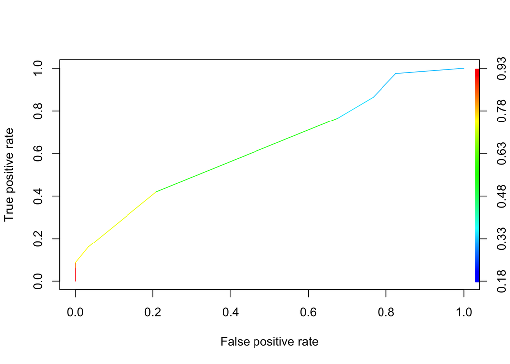

```r
# Generate a ROC and AUC output, interpret the results

# Put predictions and targets in one table
pred_tune_tibble <- tibble(pred_class=pred_tune, pred_prob=pred_tune_prob$`potable`, target=as.numeric(tune$Potability))
pred <- prediction(pred_tune_tibble$pred_prob, pred_tune_tibble$target) # use predicted prob and target at different threshold levels to build ROC curve

ROC_perf <- performance(pred,"tpr","fpr") # prediction for True Positive Rate and False Positive Rate
# TPR = TP / (TP + FN)
# FPR = FP / (FP + TN)

plot(ROC_perf, colorize=TRUE) # plot ROC curve
```

```r
tree_perf_AUC <- performance(pred,"auc")  # calculate auc on the predictions
tree_perf_AUC@y.values
```

```
## [[1]]
## [1] 0.6326132
```

# We didn’t include this part into our final presentation because we didn’t see any noticeable change in statistics (accuracy, sensitivity, specificity)

## Please consider that this part as a reference

### Another method to see if we make a better model using different method

```r
# load the data
water_quality <- read.csv("~/Desktop/R/water-quality-project/water_potability.csv")
# data cleaning
water_quality <- water_quality[complete.cases(water_quality), ]
# factorize
water_quality$Potability <- as.factor(water_quality$Potability)
water_quality$Potability <- fct_collapse(water_quality$Potability,
                           potable = "1",
                           non_potable = "0")
```

```r
set.seed(777)
partition <- caret::createDataPartition(water_quality$Potability,
                                           times=1,
                                           p = 0.80,
                                           groups=1,
                                           list=FALSE)
train <- water_quality[partition, ]
tune_and_test <- water_quality[-partition, ]
#train

tune_and_test_index <- createDataPartition(tune_and_test$Potability,
                                           p = .5,
                                           list = FALSE,
                                           times = 1)

tune <- tune_and_test[tune_and_test_index, ]
test <- tune_and_test[-tune_and_test_index, ]

dim(train)
```

```
## [1] 1609   10
```

```r
dim(test)
```

```
## [1] 201  10
```

```r
dim(tune)
```

```
## [1] 201  10
```

```r
# Build the model
# Choose the features and classes, slightly different approach for caret, need to create features and target sets from the training data.
features <- train[,-10] # dropping the target variable
target <- train$Potability

fitControl <- trainControl(method = "repeatedcv",
                          number = 10,
                          repeats = 5,
                          returnResamp = "all",
                          classProbs = TRUE,
                          allowParallel = TRUE,
                          summaryFunction = twoClassSummary)



grid <- expand.grid(.winnow = c(TRUE,FALSE), # try with reducing the feature space and without
                    .trials=c(1,5,10,15,20), # number of boosting iterations to try
                    .model="tree")  # use a decision tree model

set.seed(777)  # set seed for reproducibility
new_mdl <- train(x=features,  # train the model with the features to predict the target, salary
                y=target,
                method="C5.0",  # use C5.0 model that works by splitting the tree based on maximum info gain
                tuneGrid=grid,
                trControl=fitControl,
                verbose=TRUE)

new_mdl
```

```
## C5.0
##
## 1609 samples
##    9 predictor
##    2 classes: 'non_potable', 'potable'
##
## No pre-processing
## Resampling: Cross-Validated (10 fold, repeated 5 times)
## Summary of sample sizes: 1448, 1448, 1448, 1448, 1448, 1448, ...
## Resampling results across tuning parameters:
##
##   winnow  trials  ROC        Sens       Spec
##   FALSE    1      0.5982272  0.8516667  0.2888942
##   FALSE    5      0.6038105  0.8354167  0.3085865
##   FALSE   10      0.6038105  0.8354167  0.3085865
##   FALSE   15      0.6038105  0.8354167  0.3085865
##   FALSE   20      0.6038105  0.8354167  0.3085865
##    TRUE    1      0.5683091  0.8941667  0.2130288
##    TRUE    5      0.5725783  0.8897917  0.2164135
##    TRUE   10      0.5725783  0.8897917  0.2164135
##    TRUE   15      0.5725783  0.8897917  0.2164135
##    TRUE   20      0.5725783  0.8897917  0.2164135
##
## Tuning parameter 'model' was held constant at a value of tree
## ROC was used to select the optimal model using the largest value.
## The final values used for the model were trials = 5, model = tree and winnow
##  = FALSE.
```

```r
varImp(new_mdl)
```

```
## C5.0 variable importance
##
##                  Overall
## Sulfate         100.0000
## ph               99.0407
## Solids           79.4224
## Hardness         50.9541
## Chloramines      44.9304
## Turbidity         1.4647
## Trihalomethanes   1.0211
## Organic_carbon    0.4435
## Conductivity      0.0000
```

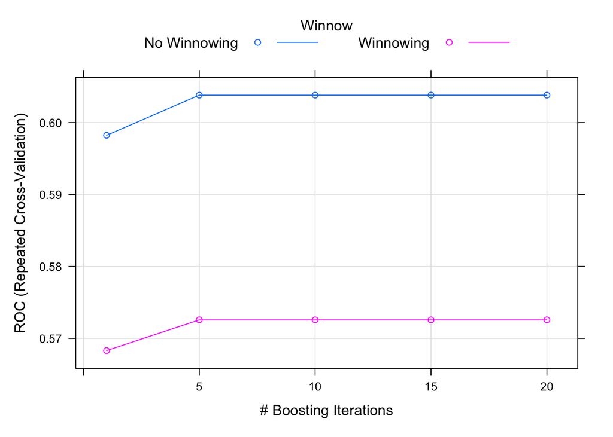

```r
plot(new_mdl)
```

```r
predictandCM(new_mdl, tune, "raw", tune$Potability)
```

```
## Confusion Matrix and Statistics
##
##              Reference
## Prediction    non_potable potable
##   non_potable         100      52
##   potable              20      29
##
##                Accuracy : 0.6418
##                  95% CI : (0.5713, 0.708)
##     No Information Rate : 0.597
##     P-Value [Acc > NIR] : 0.1102984
##
##                   Kappa : 0.2045
##
##  Mcnemar's Test P-Value : 0.0002588
##
##             Sensitivity : 0.3580
##             Specificity : 0.8333
##          Pos Pred Value : 0.5918
##          Neg Pred Value : 0.6579
##              Prevalence : 0.4030
##          Detection Rate : 0.1443
##    Detection Prevalence : 0.2438
##       Balanced Accuracy : 0.5957
##
##        'Positive' Class : potable
##
```

```r
water_pred_tune = predict(new_mdl,tune,tune$Potability, type= "prob")
water_pred_tune_labels = predict(new_mdl,tune,tune$Potability,type = "raw")
#plot(density(water_pred_tune$non_potable))
```

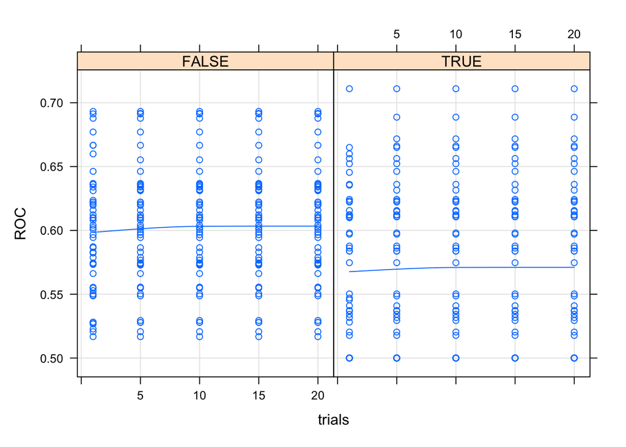

```r
# visualize the re-sample distributions with different winnows and trials
xyplot(new_mdl,type = c("g", "p", "smooth"))
```

```r
# estimate the target variable.
set.seed(777)  # set seed
pred_tune = predict(new_mdl,tune)  # predict using the model on the tune set

pred_tune_prob <- predict(new_mdl,tune, tune, type = "prob")  # save the raw probabilities for each observation being in the positive or negative class

probs_and_results <- cbind(pred_tune_prob, data.frame(`actual_potability`= tune$Potability))

head(probs_and_results)
```

```
##     non_potable   potable actual_potability
## 37    0.8702400 0.1297600       non_potable
## 54    0.7591609 0.2408391       non_potable
## 96    0.7613888 0.2386112       non_potable
## 125   0.8399627 0.1600373       non_potable
## 132   0.8702400 0.1297600       non_potable
## 151   0.2525433 0.7474567       non_potable
```

### Predicted vs. Actual Target Matrix

```r
table(as.factor(pred_tune), as.factor(tune$Potability))
```

```
##
##               non_potable potable
##   non_potable         100      52
##   potable              20      29
```

### Confusion Matrix with Model on Tune Set

```r
# Use the the confusion matrix function to check a variety of metrics
# and comment on the metric that might be best for this type of analysis given your question.
set.seed(777)
eval <- confusionMatrix(as.factor(pred_tune),   # confusion matrix on the predictions and actual values
                as.factor(tune$Potability),
                positive='potable',  # assign the positive class
                dnn=c("Prediction", "Actual"),
                mode = "everything")  # output all evaluation metrics


eval
```

```
## Confusion Matrix and Statistics
##
##              Actual
## Prediction    non_potable potable
##   non_potable         100      52
##   potable              20      29
##
##                Accuracy : 0.6418
##                  95% CI : (0.5713, 0.708)
##     No Information Rate : 0.597
##     P-Value [Acc > NIR] : 0.1102984
##
##                   Kappa : 0.2045
##
##  Mcnemar's Test P-Value : 0.0002588
##
##             Sensitivity : 0.3580
##             Specificity : 0.8333
##          Pos Pred Value : 0.5918
##          Neg Pred Value : 0.6579
##               Precision : 0.5918
##                  Recall : 0.3580
##                      F1 : 0.4462
##              Prevalence : 0.4030
##          Detection Rate : 0.1443
##    Detection Prevalence : 0.2438
##       Balanced Accuracy : 0.5957
##
##        'Positive' Class : potable
##
```

### ROC and AUC

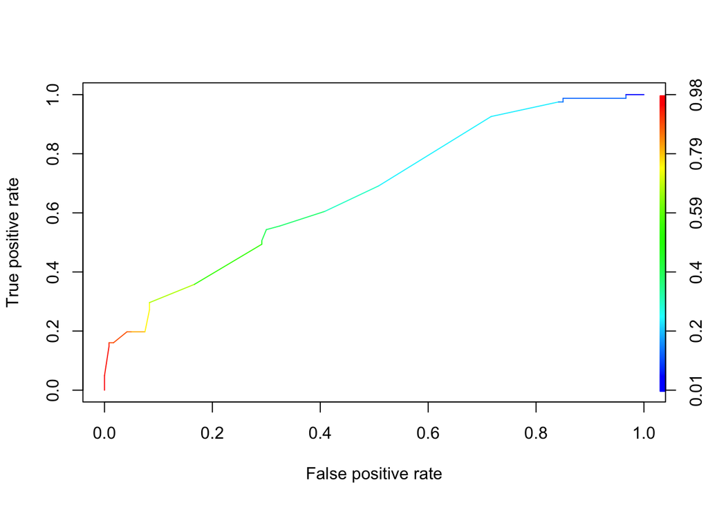

```r
# Generate a ROC and AUC output, interpret the results

# Put predictions and targets in one table
pred_tune_tibble <- tibble(pred_class=pred_tune, pred_prob=pred_tune_prob$`potable`, target=as.numeric(tune$Potability))

pred <- prediction(pred_tune_tibble$pred_prob, pred_tune_tibble$target) # use predicted prob and target at different threshold levels to build ROC curve

ROC_perf <- performance(pred,"tpr","fpr") # prediction for True Positive Rate and False Positive Rate
# TPR = TP / (TP + FN)
# FPR = FP / (FP + TN)

plot(ROC_perf, colorize=TRUE) # plot ROC curve
```

```r
tree_perf_AUC <- performance(pred,"auc")  # calculate auc on the predictions

tree_perf_AUC@y.values
```

```
## [[1]]
## [1] 0.6709362
```

### Evaluate Model with Different Hyper-Parameters

```r
fitControl2 <- trainControl(method = "LGOCV",  # Use leave group out cross validation with 5 folds
                          number = 5,
                          returnResamp="all",
                          classProbs = TRUE,
                          allowParallel = TRUE)

grid2 <- expand.grid(.winnow = c(TRUE,FALSE), # try with reducing the feature space and without
                    .trials=c(1,5,10,15,20,25,30,40),   # number of boosting iterations to try - add greater values
                    .model="tree") # use a decision tree model


set.seed(777)  # set seed for reproducibility
new_mdl2 <- train(x=features,  # train the model again with the new hyper-parameters
                y=target,
                method="C5.0",
                tuneGrid=grid2,
                trControl=fitControl2,
                verbose=TRUE)


set.seed(777) # set seed for reproducibility
pred_tune2 = predict(new_mdl2,tune, type= "prob")$`potable` # predict with the new model on the tune data
set.seed(1)

thres_tune2 <- as.factor(ifelse(pred_tune2 > 0.6, "potable","non_potable"))  # compare the predictions to the 0.4 threshold

eval2 <- confusionMatrix(as.factor(thres_tune2),   # evaluate the new predictions from the new model
                as.factor(tune$Potability),
                positive='potable',
                dnn=c("Prediction", "Actual"),
                mode = "everything")  # output all of the evaluation metric

eval2
```

```
## Confusion Matrix and Statistics
##
##              Actual
## Prediction    non_potable potable
##   non_potable         110      57
##   potable              10      24
##
##                Accuracy : 0.6667
##                  95% CI : (0.5969, 0.7314)
##     No Information Rate : 0.597
##     P-Value [Acc > NIR] : 0.02518
##
##                   Kappa : 0.2351
##
##  Mcnemar's Test P-Value : 1.912e-08
##
##             Sensitivity : 0.2963
##             Specificity : 0.9167
##          Pos Pred Value : 0.7059
##          Neg Pred Value : 0.6587
##               Precision : 0.7059
##                  Recall : 0.2963
##                      F1 : 0.4174
##              Prevalence : 0.4030
##          Detection Rate : 0.1194
##    Detection Prevalence : 0.1692
##       Balanced Accuracy : 0.6065
##
##        'Positive' Class : potable
##
```